# Assignment

Giacomo

7/8/2021

*Exercise 0* eval(FALSE) bnames10 %>% str_detect(“A”)

bnames10 %>% str_subset(“th”)

bnames10 %>% str_extract(“th”)

test <- c(“has.a.period”, “has_no_period”, “hasNoPunctuation”) test %>% str_detect(“.”)

bnamesearly %>% str_subset(fixed(“ez”))

````
```r
library(Rsubread)
readCounts <- featureCounts(
  files=c("../assigment_8/output/tophat_out-IMB211_All_A01_INTERNODE.fq/accepted_hits_A01.bam",
    "../assigment_8/output/tophat_out-R500_All_A01_INTERNODE.fq/accepted_hits_A01.bam"),
  annot.ext="../Assignment_09/input/Brapa_reference/Brapa_gene_v1.5.gtf",
  isGTFAnnotationFile=TRUE,
  GTF.featureType="CDS", # This depends on GTF file.  Often it would be "exon"
  GTF.attrType="gene_id"
  )
````

[output not shown]

*Exercise 1* 1.

```r
head(readCounts$counts)
```

```
##           ../assigment_8/output/tophat_out-IMB211_All_A01_INTERNODE.fq/accepted_hits_A01.bam
## Bra000001                                                                                  0
## Bra000002                                                                                  0
## Bra000003                                                                                  0
## Bra000004                                                                                  0
## Bra000005                                                                                  0
## Bra000006                                                                                  0
##           ../assigment_8/output/tophat_out-R500_All_A01_INTERNODE.fq/accepted_hits_A01.bam
## Bra000001                                                                                0
## Bra000002                                                                                0
## Bra000003                                                                                0
## Bra000004                                                                                0
## Bra000005                                                                                0
## Bra000006                                                                                0
```

```r
readCounts$counts["Bra011030",]
```

```
## ../assigment_8/output/tophat_out-IMB211_All_A01_INTERNODE.fq/accepted_hits_A01.bam
##                                                                               1524
##   ../assigment_8/output/tophat_out-R500_All_A01_INTERNODE.fq/accepted_hits_A01.bam
##                                                                               1987
```

```r
library(devtools)
library(dplyr)
readCounts$stat
```

```
##                           Status
## 1                       Assigned
## 2            Unassigned_Unmapped
## 3           Unassigned_Read_Type
## 4           Unassigned_Singleton
## 5      Unassigned_MappingQuality
## 6             Unassigned_Chimera
## 7      Unassigned_FragmentLength
## 8           Unassigned_Duplicate
## 9        Unassigned_MultiMapping
## 10          Unassigned_Secondary
## 11           Unassigned_NonSplit
## 12         Unassigned_NoFeatures
## 13 Unassigned_Overlapping_Length
## 14          Unassigned_Ambiguity
```

[output cut: 30 more lines]

```r
total_counts <- readCounts$stat[,c(2, 3)] %>%
  colSums()
readCounts$stat[1 , c(2, 3)] / total_counts * 100
```

```
##   ../assigment_8/output/tophat_out-IMB211_All_A01_INTERNODE.fq/accepted_hits_A01.bam
## 1                                                                           85.94902
##   ../assigment_8/output/tophat_out-R500_All_A01_INTERNODE.fq/accepted_hits_A01.bam
## 1                                                                         86.01138
```

```r
total_unassigned <- readCounts$stat[c(12, 14),c(2, 3)] %>%
  colSums()
total_unassigned / total_counts * 100
```

```
## ../assigment_8/output/tophat_out-IMB211_All_A01_INTERNODE.fq/accepted_hits_A01.bam
##                                                                           14.05098
##   ../assigment_8/output/tophat_out-R500_All_A01_INTERNODE.fq/accepted_hits_A01.bam
##                                                                           13.98862
```

4. The reason some of the maps could be unassigned could be because they were equally nicely mapped at two points which means the computer is unable to decipher which point fits better. No features just means that there were no points that really matched with any of the reference genome. Because of how many reads are said to be there I doubt it is just a mistake. It probably has something to do with a mistake in the quality control.

*Exercise 2* 1.

```r
library(tidyverse)
counts.data <- read_tsv("../Assignment_09/input/gh_internode_counts2.tsv")
counts.data
```

```
## # A tibble: 40,991 x 13
##    gene_id  IMB211_DP_1_INTE~ IMB211_DP_2_INT~ IMB211_DP_3_INT~ IMB211_NDP_1_IN~
##    <chr>                <dbl>            <dbl>            <dbl>            <dbl>
##  1 *                   805530           245831           740348           574103
##  2 Bra0000~                 1               NA               NA                2
##  3 Bra0000~                20               25               36               39
##  4 Bra0000~               228               73              184              149
##  5 Bra0000~                 8                2                7                2
##  6 Bra0000~               328               92              284              300
##  7 Bra0000~               112               45               70              133
##  8 Bra0000~                12                6               24                7
##  9 Bra0000~                20                8               16               20
## 10 Bra0000~               260              106              215              288
## # ... with 40,981 more rows, and 8 more variables:
## #   IMB211_NDP_2_INTERNODE.1_matched.merged.fq.bam <dbl>,
## #   IMB211_NDP_3_INTERNODE.1_matched.merged.fq.bam <dbl>,
## #   R500_DP_1_INTERNODE.1_matched.merged.fq.bam <dbl>,
## #   R500_DP_2_INTERNODE.1_matched.merged.fq.bam <dbl>,
## #   R500_DP_3_INTERNODE.1_matched.merged.fq.bam <dbl>,
## #   R500_NDP_1_INTERNODE.1_matched.merged.fq.bam <dbl>,
## #   R500_NDP_2_INTERNODE.1_matched.merged.fq.bam <dbl>,
## #   R500_NDP_3_INTERNODE.1_matched.merged.fq.bam <dbl>
```

2. The data makes sense to me. I dont know if there is something that is out of place or different. I noticed the `*` and the NA values which are a bit odd. It could simply mean 0.

```r
counts.data <- counts.data %>% filter(gene_id!="*")
counts.data[is.na(counts.data)] <- 0
counts.data
```

```
## # A tibble: 40,990 x 13
##    gene_id  IMB211_DP_1_INTE~ IMB211_DP_2_INT~ IMB211_DP_3_INT~ IMB211_NDP_1_IN~
##    <chr>                <dbl>            <dbl>            <dbl>            <dbl>
##  1 Bra0000~                 1                0                0                2
##  2 Bra0000~                20               25               36               39
##  3 Bra0000~               228               73              184              149
##  4 Bra0000~                 8                2                7                2
##  5 Bra0000~               328               92              284              300
##  6 Bra0000~               112               45               70              133
##  7 Bra0000~                12                6               24                7
##  8 Bra0000~                20                8               16               20
##  9 Bra0000~               260              106              215              288
## 10 Bra0000~                87               34              111              200
## # ... with 40,980 more rows, and 8 more variables:
## #   IMB211_NDP_2_INTERNODE.1_matched.merged.fq.bam <dbl>,
## #   IMB211_NDP_3_INTERNODE.1_matched.merged.fq.bam <dbl>,
## #   R500_DP_1_INTERNODE.1_matched.merged.fq.bam <dbl>,
## #   R500_DP_2_INTERNODE.1_matched.merged.fq.bam <dbl>,
## #   R500_DP_3_INTERNODE.1_matched.merged.fq.bam <dbl>,
## #   R500_NDP_1_INTERNODE.1_matched.merged.fq.bam <dbl>,
## #   R500_NDP_2_INTERNODE.1_matched.merged.fq.bam <dbl>,
## #   R500_NDP_3_INTERNODE.1_matched.merged.fq.bam <dbl>
```

*Exercise 3* 1.

```r
data(iris)
colnames(iris)
```

```
## [1] "Sepal.Length" "Sepal.Width"  "Petal.Length" "Petal.Width"  "Species"
```

```r
colnames(iris) <- str_replace(colnames(iris), fixed("."), " ")
colnames(iris)
```

```
## [1] "Sepal Length" "Sepal Width"  "Petal Length" "Petal Width"  "Species"
```

```r
colnames(counts.data)
```

```
##  [1] "gene_id"
##  [2] "IMB211_DP_1_INTERNODE.1_matched.merged.fq.bam"
##  [3] "IMB211_DP_2_INTERNODE.1_matched.merged.fq.bam"
##  [4] "IMB211_DP_3_INTERNODE.1_matched.merged.fq.bam"
##  [5] "IMB211_NDP_1_INTERNODE.1_matched.merged.fq.bam"
##  [6] "IMB211_NDP_2_INTERNODE.1_matched.merged.fq.bam"
##  [7] "IMB211_NDP_3_INTERNODE.1_matched.merged.fq.bam"
##  [8] "R500_DP_1_INTERNODE.1_matched.merged.fq.bam"
##  [9] "R500_DP_2_INTERNODE.1_matched.merged.fq.bam"
## [10] "R500_DP_3_INTERNODE.1_matched.merged.fq.bam"
## [11] "R500_NDP_1_INTERNODE.1_matched.merged.fq.bam"
## [12] "R500_NDP_2_INTERNODE.1_matched.merged.fq.bam"
## [13] "R500_NDP_3_INTERNODE.1_matched.merged.fq.bam"
```

```r
colnames(counts.data) <- str_replace(colnames(counts.data), fixed(".1_matched.merged.fq.bam"), "")
colnames(counts.data)
```

```
##  [1] "gene_id"                "IMB211_DP_1_INTERNODE"  "IMB211_DP_2_INTERNODE"
##  [4] "IMB211_DP_3_INTERNODE"  "IMB211_NDP_1_INTERNODE" "IMB211_NDP_2_INTERNODE"
##  [7] "IMB211_NDP_3_INTERNODE" "R500_DP_1_INTERNODE"    "R500_DP_2_INTERNODE"
## [10] "R500_DP_3_INTERNODE"    "R500_NDP_1_INTERNODE"   "R500_NDP_2_INTERNODE"
## [13] "R500_NDP_3_INTERNODE"
```

```r
counts.data
```

```
## # A tibble: 40,990 x 13
##    gene_id  IMB211_DP_1_INTE~ IMB211_DP_2_INT~ IMB211_DP_3_INT~ IMB211_NDP_1_IN~
##    <chr>                <dbl>            <dbl>            <dbl>            <dbl>
##  1 Bra0000~                 1                0                0                2
##  2 Bra0000~                20               25               36               39
##  3 Bra0000~               228               73              184              149
##  4 Bra0000~                 8                2                7                2
##  5 Bra0000~               328               92              284              300
##  6 Bra0000~               112               45               70              133
##  7 Bra0000~                12                6               24                7
##  8 Bra0000~                20                8               16               20
##  9 Bra0000~               260              106              215              288
## 10 Bra0000~                87               34              111              200
## # ... with 40,980 more rows, and 8 more variables:
## #   IMB211_NDP_2_INTERNODE <dbl>, IMB211_NDP_3_INTERNODE <dbl>,
## #   R500_DP_1_INTERNODE <dbl>, R500_DP_2_INTERNODE <dbl>,
## #   R500_DP_3_INTERNODE <dbl>, R500_NDP_1_INTERNODE <dbl>,
## #   R500_NDP_2_INTERNODE <dbl>, R500_NDP_3_INTERNODE <dbl>
```

*Exercise 5*

```r
pairs_counts <- counts.data[, -1]
pairs_counts
```

```
## # A tibble: 40,990 x 12
##    IMB211_DP_1_INTERN~ IMB211_DP_2_INTERN~ IMB211_DP_3_INTER~ IMB211_NDP_1_INTE~
##                  <dbl>               <dbl>              <dbl>              <dbl>
##  1                   1                   0                  0                  2
##  2                  20                  25                 36                 39
##  3                 228                  73                184                149
##  4                   8                   2                  7                  2
##  5                 328                  92                284                300
##  6                 112                  45                 70                133
##  7                  12                   6                 24                  7
##  8                  20                   8                 16                 20
##  9                 260                 106                215                288
## 10                  87                  34                111                200
## # ... with 40,980 more rows, and 8 more variables:
## #   IMB211_NDP_2_INTERNODE <dbl>, IMB211_NDP_3_INTERNODE <dbl>,
## #   R500_DP_1_INTERNODE <dbl>, R500_DP_2_INTERNODE <dbl>,
## #   R500_DP_3_INTERNODE <dbl>, R500_NDP_1_INTERNODE <dbl>,
## #   R500_NDP_2_INTERNODE <dbl>, R500_NDP_3_INTERNODE <dbl>
```

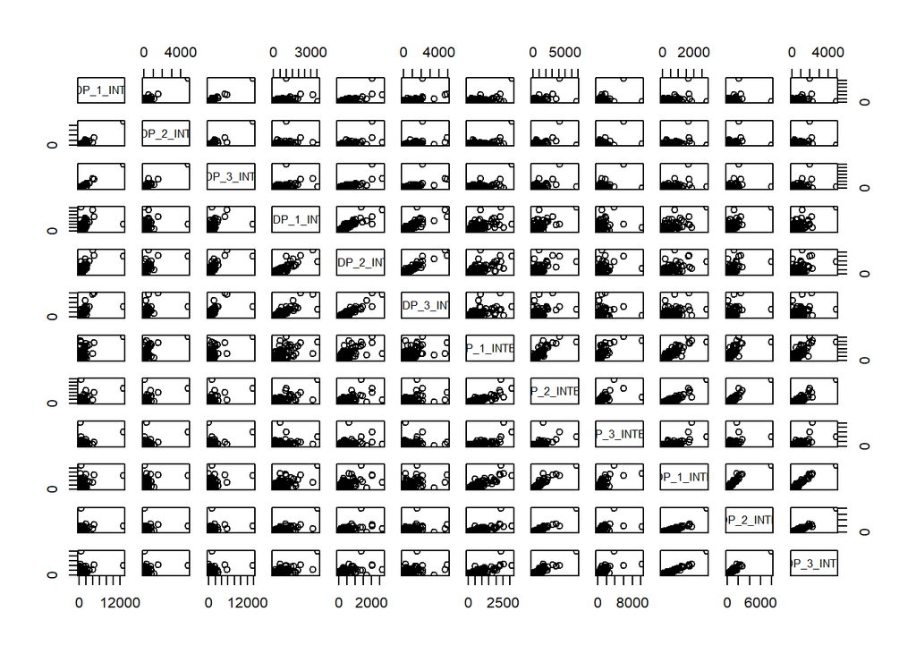

```r
pair.counts <- pairs_counts[1:1000,]
pairs(pair.counts)
```

```r
cor(pair.counts)
```

```
##                        IMB211_DP_1_INTERNODE IMB211_DP_2_INTERNODE
## IMB211_DP_1_INTERNODE              1.0000000             0.9539846
## IMB211_DP_2_INTERNODE              0.9539846             1.0000000
## IMB211_DP_3_INTERNODE              0.9872631             0.9434489
## IMB211_NDP_1_INTERNODE             0.6151860             0.4614244
## IMB211_NDP_2_INTERNODE             0.8043768             0.6680989
## IMB211_NDP_3_INTERNODE             0.7296214             0.5914334
## R500_DP_1_INTERNODE                0.6943784             0.6412368
## R500_DP_2_INTERNODE                0.6175667             0.5817560
## R500_DP_3_INTERNODE                0.5620193             0.5562543
## R500_NDP_1_INTERNODE               0.5748745             0.5300193
## R500_NDP_2_INTERNODE               0.4583251             0.4109305
## R500_NDP_3_INTERNODE               0.5174053             0.4688327
##                        IMB211_DP_3_INTERNODE IMB211_NDP_1_INTERNODE
## IMB211_DP_1_INTERNODE              0.9872631              0.6151860
## IMB211_DP_2_INTERNODE              0.9434489              0.4614244
## IMB211_DP_3_INTERNODE              1.0000000              0.6258969
## IMB211_NDP_1_INTERNODE             0.6258969              1.0000000
## IMB211_NDP_2_INTERNODE             0.8012843              0.9258920
## IMB211_NDP_3_INTERNODE             0.7454697              0.8939943
## R500_DP_1_INTERNODE                0.6611570              0.7780359
## R500_DP_2_INTERNODE                0.5985256              0.7883098
## R500_DP_3_INTERNODE                0.5287967              0.5413546
## R500_NDP_1_INTERNODE               0.5555466              0.8021692
## R500_NDP_2_INTERNODE               0.4537143              0.7955275
## R500_NDP_3_INTERNODE               0.5065779              0.7972599
##                        IMB211_NDP_2_INTERNODE IMB211_NDP_3_INTERNODE
## IMB211_DP_1_INTERNODE               0.8043768              0.7296214
## IMB211_DP_2_INTERNODE               0.6680989              0.5914334
## IMB211_DP_3_INTERNODE               0.8012843              0.7454697
## IMB211_NDP_1_INTERNODE              0.9258920              0.8939943
## IMB211_NDP_2_INTERNODE              1.0000000              0.9542158
## IMB211_NDP_3_INTERNODE              0.9542158              1.0000000
## R500_DP_1_INTERNODE                 0.8227041              0.7363193
## R500_DP_2_INTERNODE                 0.7610821              0.6531797
## R500_DP_3_INTERNODE                 0.6014519              0.4537664
## R500_NDP_1_INTERNODE                0.7771903              0.6822598
## R500_NDP_2_INTERNODE                0.6912183              0.5990565
## R500_NDP_3_INTERNODE                0.7344514              0.6371046
##                        R500_DP_1_INTERNODE R500_DP_2_INTERNODE
```

[output cut: 23 more lines]

```
## R500_NDP_2_INTERNODE             0.6951752            0.9353010
## R500_NDP_3_INTERNODE             0.7801636            0.9799512
##                        R500_NDP_2_INTERNODE R500_NDP_3_INTERNODE
## IMB211_DP_1_INTERNODE             0.4583251            0.5174053
## IMB211_DP_2_INTERNODE             0.4109305            0.4688327
## IMB211_DP_3_INTERNODE             0.4537143            0.5065779
## IMB211_NDP_1_INTERNODE            0.7955275            0.7972599
## IMB211_NDP_2_INTERNODE            0.6912183            0.7344514
## IMB211_NDP_3_INTERNODE            0.5990565            0.6371046
## R500_DP_1_INTERNODE               0.8116315            0.8773806
## R500_DP_2_INTERNODE               0.9608421            0.9564270
## R500_DP_3_INTERNODE               0.6951752            0.7801636
## R500_NDP_1_INTERNODE              0.9353010            0.9799512
## R500_NDP_2_INTERNODE              1.0000000            0.9692820
## R500_NDP_3_INTERNODE              0.9692820            1.0000000
```

1. The pairs image is difficult to read so I am not 100% sure what it means. The cor() image is showing the correlations between each of the samples numerically. I just realized that the pairs image is doing the same just as an image.

*Exercise 6*

```r
sample.description <- tibble(sample=colnames(counts.data)[-1])
sample_seperation <- sample.description %>%
  mutate(gt = str_extract(sample, "IMB211|R500"),
         trt = str_extract(sample, "DP|NDP"),
         group = str_c(gt, trt, sep = "_"))

sample_seperation
```

```
## # A tibble: 12 x 4
##    sample                 gt     trt   group
##    <chr>                  <chr>  <chr> <chr>
##  1 IMB211_DP_1_INTERNODE  IMB211 DP    IMB211_DP
##  2 IMB211_DP_2_INTERNODE  IMB211 DP    IMB211_DP
##  3 IMB211_DP_3_INTERNODE  IMB211 DP    IMB211_DP
##  4 IMB211_NDP_1_INTERNODE IMB211 NDP   IMB211_NDP
##  5 IMB211_NDP_2_INTERNODE IMB211 NDP   IMB211_NDP
##  6 IMB211_NDP_3_INTERNODE IMB211 NDP   IMB211_NDP
##  7 R500_DP_1_INTERNODE    R500   DP    R500_DP
##  8 R500_DP_2_INTERNODE    R500   DP    R500_DP
##  9 R500_DP_3_INTERNODE    R500   DP    R500_DP
## 10 R500_NDP_1_INTERNODE   R500   NDP   R500_NDP
## 11 R500_NDP_2_INTERNODE   R500   NDP   R500_NDP
## 12 R500_NDP_3_INTERNODE   R500   NDP   R500_NDP
```

```r
sample.description <- sample_seperation %>%
  mutate(gt=factor(gt),
         trt=factor(trt,levels = c("NDP","DP"))
         )


sample.description
```

```
## # A tibble: 12 x 4
##    sample                 gt     trt   group
##    <chr>                  <fct>  <fct> <chr>
##  1 IMB211_DP_1_INTERNODE  IMB211 DP    IMB211_DP
##  2 IMB211_DP_2_INTERNODE  IMB211 DP    IMB211_DP
##  3 IMB211_DP_3_INTERNODE  IMB211 DP    IMB211_DP
##  4 IMB211_NDP_1_INTERNODE IMB211 NDP   IMB211_NDP
##  5 IMB211_NDP_2_INTERNODE IMB211 NDP   IMB211_NDP
##  6 IMB211_NDP_3_INTERNODE IMB211 NDP   IMB211_NDP
##  7 R500_DP_1_INTERNODE    R500   DP    R500_DP
##  8 R500_DP_2_INTERNODE    R500   DP    R500_DP
##  9 R500_DP_3_INTERNODE    R500   DP    R500_DP
## 10 R500_NDP_1_INTERNODE   R500   NDP   R500_NDP
## 11 R500_NDP_2_INTERNODE   R500   NDP   R500_NDP
## 12 R500_NDP_3_INTERNODE   R500   NDP   R500_NDP
```

```r
library(edgeR)
counts.matrix <- counts.data %>%
  select(-gene_id) %>%
  as.matrix()
rownames(counts.matrix) <- counts.data$gene_id

dge.data <- DGEList(counts=counts.matrix,
                    group=sample.description$group)
dim(dge.data)
```

```
## [1] 40990    12
```

```r
dge.data <- calcNormFactors(dge.data, method = "TMM")
dge.data$samples
```

```
##                             group lib.size norm.factors
## IMB211_DP_1_INTERNODE   IMB211_DP  5521734    0.9557498
## IMB211_DP_2_INTERNODE   IMB211_DP  1519188    1.0469839
## IMB211_DP_3_INTERNODE   IMB211_DP  5226639    0.8818922
## IMB211_NDP_1_INTERNODE IMB211_NDP  3917021    0.9805073
## IMB211_NDP_2_INTERNODE IMB211_NDP  3093945    1.0155025
## IMB211_NDP_3_INTERNODE IMB211_NDP  4788396    0.9022484
## R500_DP_1_INTERNODE       R500_DP  4847351    1.0509579
## R500_DP_2_INTERNODE       R500_DP  5619852    1.0571052
## R500_DP_3_INTERNODE       R500_DP  5155560    1.0089932
## R500_NDP_1_INTERNODE     R500_NDP  3203773    1.0460736
## R500_NDP_2_INTERNODE     R500_NDP  4540317    1.0292862
## R500_NDP_3_INTERNODE     R500_NDP  3959111    1.0450865
```

```
## Note: the bcv method is now scheduled to be removed in a future release of edgeR.
```

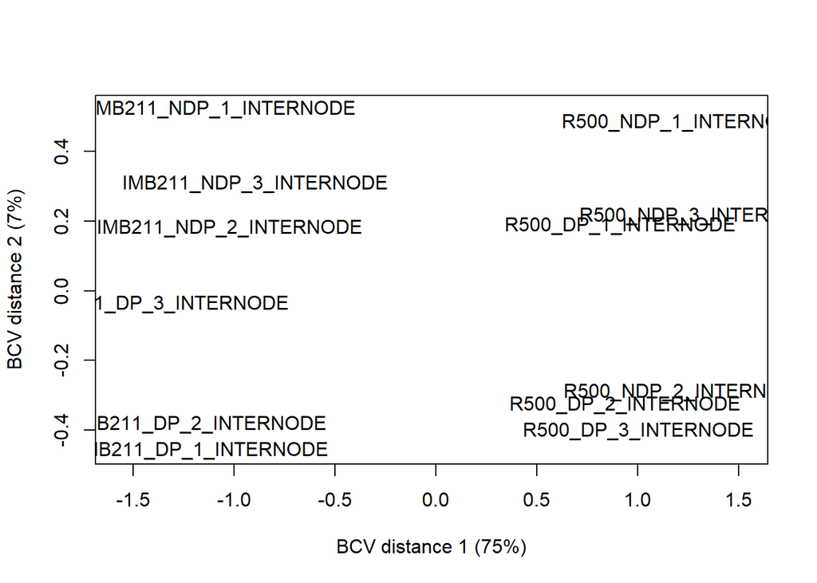

```r
plotMDS(dge.data, method = "bcv")
```

*Exercise 7* I would say the NDS plot is not super concerning because it is showing that most of the same samples are pretty close to one another.

*Exercise 8*

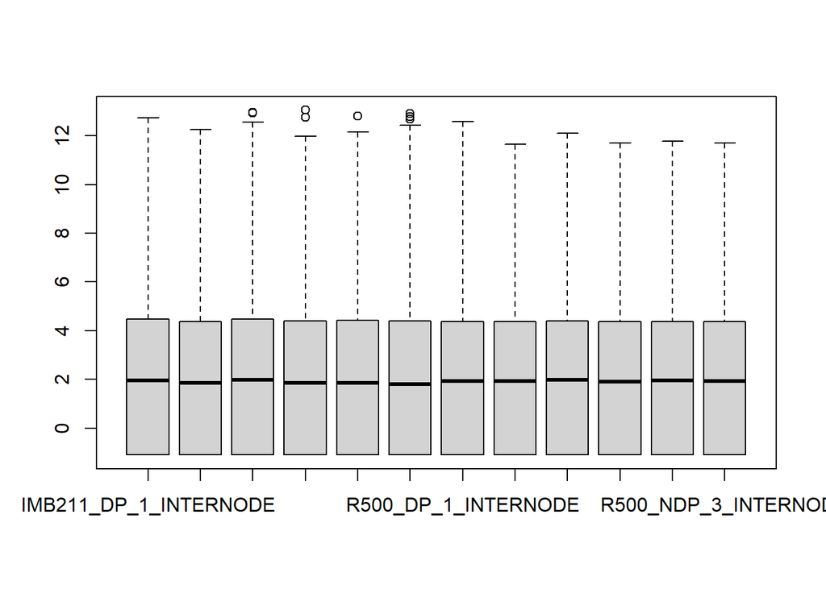

```r
counts.data.normal <- cpm(dge.data)
counts.data.normal.log <- cpm(dge.data,log = TRUE)
counts.data.log <- log2(counts.data[,-1] + 1)
boxplot(counts.data.normal.log)
```

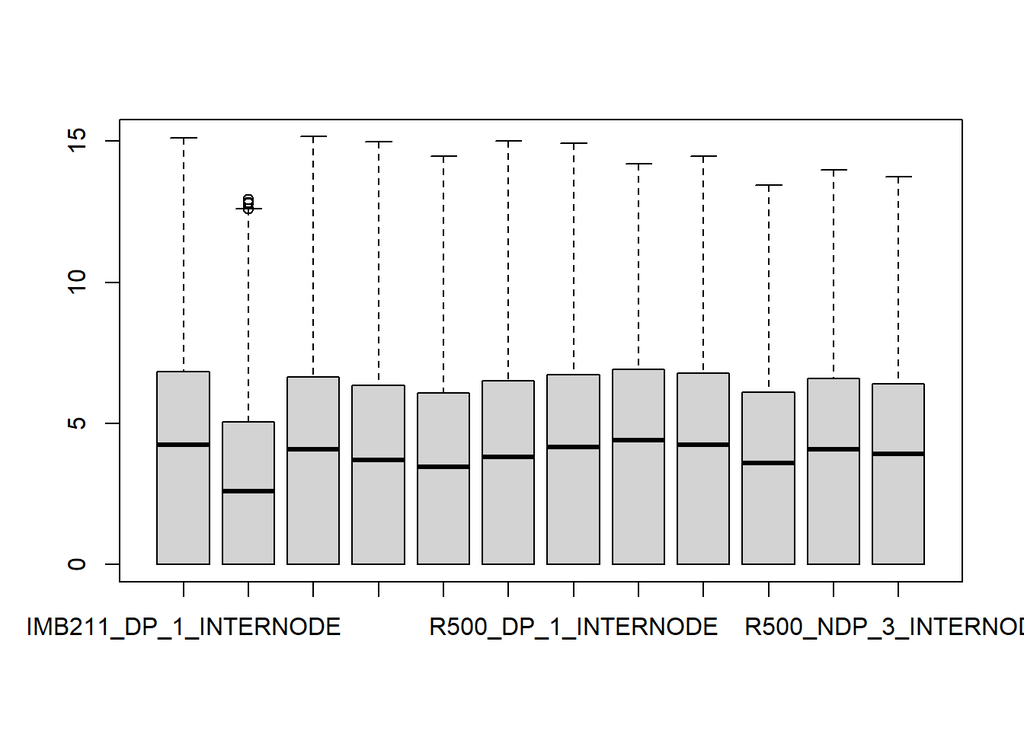

```r
boxplot(counts.data.log)
```

1. The one thing I noticed is that the data that was not normalized had a lot more variation then the one that was normalized. Another important point is that the numbers were a lot more spread in the non-normalized data. 2. Hint 3 - You need yo use this in log2 because it is using the data from counts.data which has the Gene ID column.

```r
design <- model.matrix(~gt+trt,data = sample.description)
rownames(design) <- sample.description$sample
design
```

```
##                        (Intercept) gtR500 trtDP
## IMB211_DP_1_INTERNODE            1      0     1
## IMB211_DP_2_INTERNODE            1      0     1
## IMB211_DP_3_INTERNODE            1      0     1
## IMB211_NDP_1_INTERNODE           1      0     0
## IMB211_NDP_2_INTERNODE           1      0     0
## IMB211_NDP_3_INTERNODE           1      0     0
## R500_DP_1_INTERNODE              1      1     1
## R500_DP_2_INTERNODE              1      1     1
## R500_DP_3_INTERNODE              1      1     1
## R500_NDP_1_INTERNODE             1      1     0
## R500_NDP_2_INTERNODE             1      1     0
## R500_NDP_3_INTERNODE             1      1     0
## attr(,"assign")
## [1] 0 1 2
## attr(,"contrasts")
## attr(,"contrasts")$gt
## [1] "contr.treatment"
##
## attr(,"contrasts")$trt
## [1] "contr.treatment"
```

*Exercise 9*

```r
#First the overall dispersion
dge.data <- estimateGLMCommonDisp(dge.data,design,verbose = TRUE)
```

```
## Disp = 0.06019 , BCV = 0.2453
```

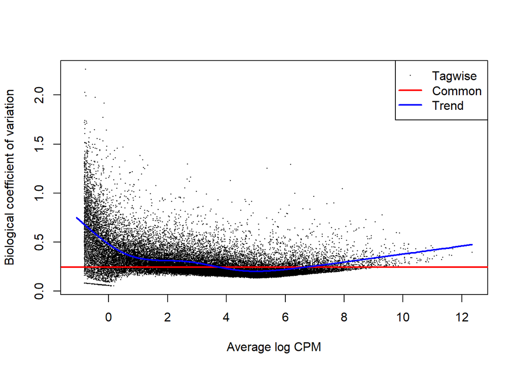

```r
#Then a trended dispersion based on count level
dge.data <- estimateGLMTrendedDisp(dge.data,design)

#And lastly we calculate the gene-wise dispersion, using the prior estimates to "squeeze" the dispersion towards the common dispersion.
dge.data <- estimateGLMTagwiseDisp(dge.data,design)

#We can examine this with a plot
plotBCV(dge.data)
```

```r
fit <- glmFit(dge.data, design)
gt.lrt <- glmLRT(fit, coef = "gtR500")
topTags(gt.lrt)
```

```
## Coefficient:  gtR500
##                logFC   logCPM       LR        PValue           FDR
## Bra033098 -12.136875 6.054431 985.1644 3.013155e-216 1.235092e-211
## Bra023495 -11.873200 5.776257 972.9466 1.363899e-213 2.795311e-209
## Bra016271 -14.234538 8.126632 904.5625 9.999935e-199 1.366325e-194
## Bra020631 -11.302422 5.191496 864.8725 4.248931e-190 4.354092e-186
## Bra011216 -11.242817 5.118382 857.4233 1.769012e-188 1.450236e-184
## Bra020643 -14.368875 8.263752 847.1829 2.978536e-186 2.034837e-182
## Bra009785   7.967047 6.021643 773.0568 3.891521e-170 2.278763e-166
## Bra029392   8.353763 6.298051 725.9757 6.718490e-160 3.442386e-156
## Bra026924  -8.313170 5.013923 720.4745 1.055544e-158 4.807418e-155
## Bra011765  -7.299692 6.327323 717.1870 5.474500e-158 2.243997e-154
```

```r
summary(decideTestsDGE(gt.lrt,p.value=0.01))
```

```
##        gtR500
## Down     6349
## NotSig  28768
## Up       5873
```

```r
DEgene.gt <- topTags(gt.lrt,n = Inf,p.value = 0.01)$table
write.csv(DEgene.gt, "../Assignment_09/DEgenes.gt.csv")

DEgene.gt.all <- topTags(gt.lrt,n = Inf,p.value = 0.01)$table
write.csv(DEgene.gt.all, "../Assignment_09/DEgenes.gt.csv")
```

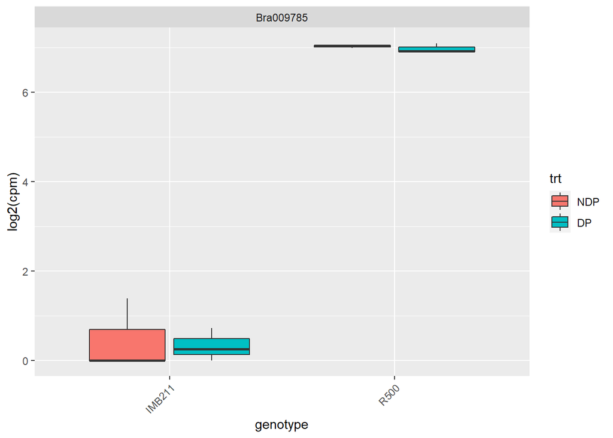

```r
plotDE <- function(genes, dge, sample.description) {
  require(ggplot2)
  tmp.data <- t(log2(cpm(dge[genes,])+1))
  tmp.data <- tmp.data %>%
    as.data.frame() %>%
    rownames_to_column("sample") %>%
    left_join(sample.description,by="sample")
  tmp.data <- tmp.data %>%
    pivot_longer(cols=starts_with("Bra"), values_to = "log2_cpm", names_to = "gene")
  pl <- ggplot(tmp.data,aes(x=gt,y=log2_cpm,fill=trt))
  pl <- pl + facet_wrap( ~ gene)
  pl <- pl + ylab("log2(cpm)") + xlab("genotype")
  pl <- pl + geom_boxplot()
  pl + theme(axis.text.x  = element_text(angle=45, vjust=1,hjust=1))
}

plotDE("Bra009785",dge.data,sample.description)
```

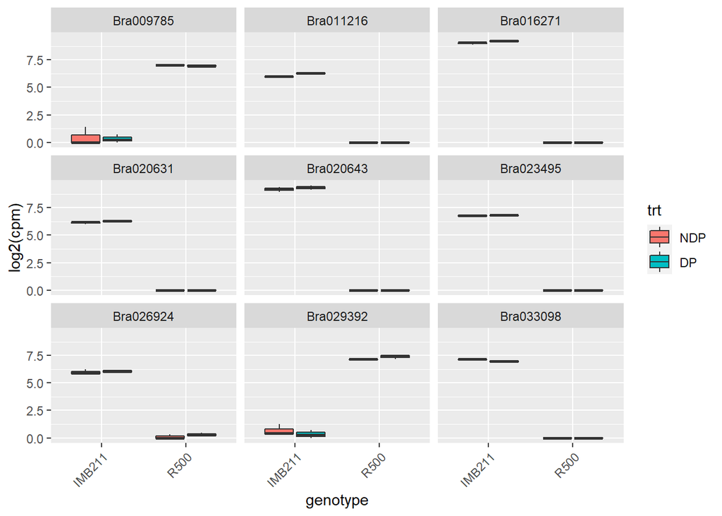

```r
plotDE(rownames(DEgene.gt)[1:9],dge.data,sample.description)
```

1. & 3.

```r
fit <- glmFit(dge.data, design)
trtDP.lrt <- glmLRT(fit, coef = "trtDP")
topTags(trtDP.lrt)
```

```
## Coefficient:  trtDP
##               logFC   logCPM        LR       PValue          FDR
## Bra028803 -5.048105 3.517786 131.41047 2.013543e-30 8.253513e-26
## Bra019324  4.806102 2.203020  75.86478 3.037708e-18 6.225782e-14
## Bra034565  4.077644 2.153468  68.98667 9.913132e-17 1.354464e-12
## Bra025587  4.170559 3.285548  56.51649 5.572913e-14 5.710842e-10
## Bra030161  2.838412 5.090649  47.82298 4.664918e-12 3.772078e-08
## Bra037739  2.030157 4.529895  47.49251 5.521461e-12 3.772078e-08
## Bra016050  5.095016 1.749409  46.72858 8.153122e-12 4.774235e-08
## Bra029946  2.281648 5.353031  46.35695 9.855714e-12 5.049822e-08
## Bra029042  3.494321 1.236372  45.73143 1.356290e-11 5.731355e-08
## Bra026156  1.763497 6.468495  45.67177 1.398233e-11 5.731355e-08
```

```r
summary(decideTestsDGE(trtDP.lrt,p.value=0.01))
```

```
##        trtDP
## Down     168
## NotSig 40417
## Up       405
```

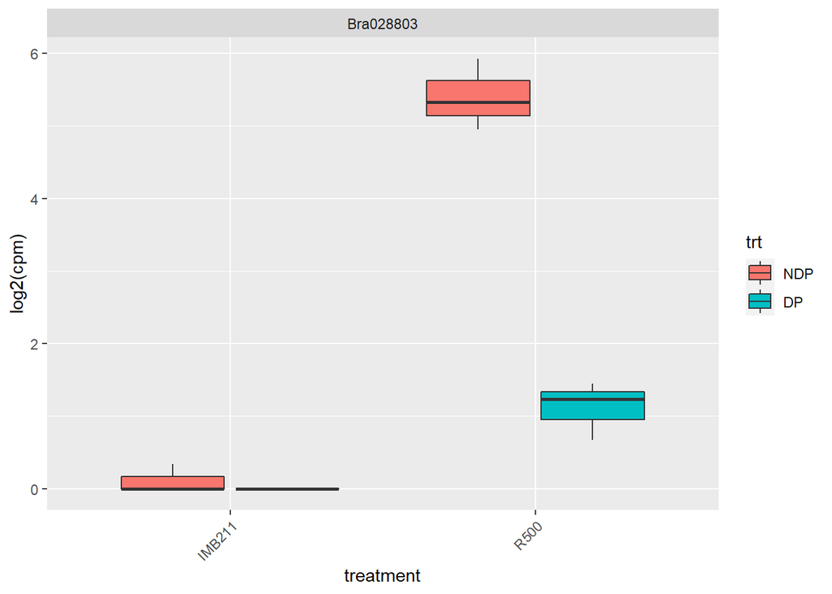

```r
DEgene.trtDP <- topTags(trtDP.lrt,n = Inf,p.value = 0.01)$table
write.csv(DEgene.trtDP, "../Assignment_09/DEgenes.trt.csv")

DEgene.trtDP.all <- topTags(trtDP.lrt,n = Inf,p.value = 0.01)$table
write.csv(DEgene.trtDP.all, "../Assignment_09/DEgenes.trtDP.csv")


plotDE <- function(genes, dge, sample.description) {
  require(ggplot2)
  tmp.data <- t(log2(cpm(dge[genes,])+1))
  tmp.data <- tmp.data %>%
    as.data.frame() %>%
    rownames_to_column("sample") %>%
    left_join(sample.description,by="sample")
  tmp.data <- tmp.data %>%
    pivot_longer(cols=starts_with("Bra"), values_to = "log2_cpm", names_to = "gene")
  pl <- ggplot(tmp.data,aes(x=gt,y=log2_cpm,fill=trt))
  pl <- pl + facet_wrap( ~ gene)
  pl <- pl + ylab("log2(cpm)") + xlab("treatment")
  pl <- pl + geom_boxplot()
  pl + theme(axis.text.x  = element_text(angle=45, vjust=1,hjust=1))
}

plotDE("Bra028803",dge.data,sample.description)
```

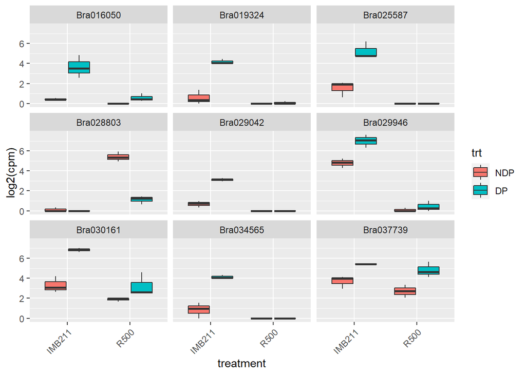

```r
plotDE(rownames(DEgene.trtDP)[1:9],dge.data,sample.description)
```

2. 573 genes were differentially expressed.